# # RNA-seq Data Processing for Context-Specific Salmonella GEM Construction with iMATpy

Gina Vazquez

## Notes

### 02/09 - 02/13

Options for the iMATpy data integration workflow:

1. Normalize the counts for gene length and sequencing depth
   - Options are RLE with DESeq2, CPM or TMM with edgeR, and TPM/FPKM.
2. The iMATpy documentation suggests quantile normalizing?
3. Combine the gene expression values of the replicates
   - Average the five replicates per condition
   - Run iMAT per replicate
   - Build a model for each replicate and then intersect them

### 02/16 - 02/17

- I’m not sure what difference there is between using VST, CPM/TMM, and FPKM/TPM.
- I need to have a featurecounts (fc) table of the entire Metatranscriptome to properly normalize to library size. Currently, the fc tables are a subset of the salmonella genes from the original table. The original table also does not include the mouse genome so I need to change to Snakemake workflow to make a Featurecounts table inclusive of the entire Metranscriptome.
- Let’s try DeSeq2 median of ratios first and then EdgeR TMM since these were the most accurate in [this paper.](https://www.nature.com/articles/s41540-024-00448-z).

### 02/18

- Thresholding values to try: <25% and >75%, <10% and >90%, and <15% and >85%.
  - I’m basing this on two papers: [(Çakir et al., 2024)](https://www.nature.com/articles/s41540-024-00448-z) and [(Lewis et al., 2017)](https://pubmed.ncbi.nlm.nih.gov/28215528/).
- Question: Do I do this combined for both conditions or seperate?
  - Some papers do the thresholding at a global scale regardless of condition. - look into the point of this and do it.
- Get total count for genes kept and lost for each threshold.
- Get gene names kept and lost.
- Get how many genes with a count of 0 (from the raw data) are kept and lost.
  - Check how many genes with a count of 0 in raw and normalized.

## Notes to Self

- The featurecounts table should be regenerated for the entire metatranscriptome.
- Still need to match the gene_ids to the GEM gene_ids.
- Compare RLE normalization to TMM normalization results.
  - Worth considering: Recalculate DGE and cross-reference the over/under expressed genes to the threshold list(s).
- Double check if aggregating the replicates is the approach.
  - Another thought is that the replicates could be aggregated after thresholding. (Does that even make sense?)
- The Çakir paper determines the thresholds based on all samples regardless of condition.
  - I’m not sure why or what difference it makes? (Something to discuss on 02/19 meeting) -Get the gene_ids for the genes in the high_differ and low_differ colums of the reports. These are the same as combining the mixed_only and stm_only lists from the comparison lists for both high and low and across thresholds.
- **Read [(Çakir et al., 2024)](https://www.nature.com/articles/s41540-024-00448-z) to see how they prepped the data - it seems most accurate.**

## Future Work from SW/TB 02/19 Meeting

- Regenerate the featurecounts table from the entire metatranscriptome.
  - Will need to rerun the snakemake workflow.
    - Must transfer data and files from local to Farm.
- Compare RLE and TMM normalization results.
  - These are the best performing in [this paper.](https://www.nature.com/articles/s41540-024-00448-z)
- Post-Normalization Questions:
  - How do I visualize RLE/TMM normalized data?
  - Can they be plotted on log2?
- Averaging replicates:
  - Can I take the mean of the replicates or do I take the geometric mean? (This is a concern from SW)
    - Another alternative for dealing with replicates?
- Thresholding:
  - I designated 1, -1, 0 genes per condition though one study designated the values based on the expression levels of all samples and conditions in this paper.
    - **Double check this source.**
    - What is the value/difference in doing this?
- Evaluating Results:
  - Compare the genes categorized as high and low per condition to DGE analysis.
    - **Find this paper** - uses DGE to assign the 1, -1, 0 values which is something to look into.

## Terminal Commands

```bash
# do not run, these are for notekeeping
scp /Users/gina/Documents/rnaseq_prelim/exp_stm.csv gmvaz@farm.cse.ucdavis.edu:/home/gmvaz/2026_GEMs
```

## Read in FeatureCounts Table

```r
df = read.delim("stm_counts_v4.txt", skip = 1, header = TRUE, row.names = 1, stringsAsFactors = FALSE)
df_stm = df[c("sam.278.1_stm.sorted.bam",   "sam.278.2_stm.sorted.bam",    "sam.278.3_stm.sorted.bam",    "sam.278.4_stm.sorted.bam",    "sam.278.5_stm.sorted.bam",    "sam.279.1_stm.sorted.bam",    "sam.279.2_stm.sorted.bam",    "sam.279.3_stm.sorted.bam",    "sam.279.4_stm.sorted.bam",    "sam.279.5_stm.sorted.bam")]

colnames(df_stm) = c("278.1", "278.2", "278.3", "278.4", "278.5",
                      "279.1", "279.2", "279.3", "279.4", "279.5")


head(df_stm)
```

```
##         278.1 278.2 278.3 278.4 278.5 279.1 279.2 279.3 279.4 279.5
## STM0001    21    53    13    46    16    75   201    40   144    11
## STM0002    27   158   175    96    50   317   353   106   154    97
## STM0003    11    73   107    48    27   130   214    79   102    51
## STM0004    30   182   181    91    58   263   391   150   198    92
## STM0005    13    83   103    58    22   135   135    71    93    44
## STM0006     9    68    58    38    29   109   167    89    87    27
```

## Read in the Sample Metadata

```r
csv_exp_stm = read.csv("exp_stm.csv")
print(csv_exp_stm)
```

```
##                      sample condition
## 1  sam.278.1_stm.sorted.bam cs/bt/stm
## 2  sam.278.2_stm.sorted.bam cs/bt/stm
## 3  sam.278.3_stm.sorted.bam cs/bt/stm
## 4  sam.278.4_stm.sorted.bam cs/bt/stm
## 5  sam.278.5_stm.sorted.bam cs/bt/stm
## 6  sam.279.1_stm.sorted.bam       stm
## 7  sam.279.2_stm.sorted.bam       stm
## 8  sam.279.3_stm.sorted.bam       stm
## 9  sam.279.4_stm.sorted.bam       stm
## 10 sam.279.5_stm.sorted.bam       stm
```

## Make the DeSeq2 Object

```r
dds = DESeqDataSetFromMatrix(
    countData = df_stm,
    colData = csv_exp_stm,
    design = ~ condition
)
```

```
##   Note: levels of factors in the design contain characters other than
##   letters, numbers, '_' and '.'. It is recommended (but not required) to use
##   only letters, numbers, and delimiters '_' or '.', as these are safe characters
##   for column names in R. [This is a message, not a warning or an error]
```

## RLE Normalization

```r
# calculates a size factor for each sample
dds = estimateSizeFactors(dds)
```

```
##   Note: levels of factors in the design contain characters other than
##   letters, numbers, '_' and '.'. It is recommended (but not required) to use
##   only letters, numbers, and delimiters '_' or '.', as these are safe characters
##   for column names in R. [This is a message, not a warning or an error]
```

```r
#prints the scaling factor
sizeFactors(dds)
```

```
##     278.1     278.2     278.3     278.4     278.5     279.1     279.2     279.3
## 0.3027193 1.0829288 1.2906635 0.7478783 0.5102895 1.8820667 2.7753455 1.3405013
##     279.4     279.5
## 1.6899401 0.5744041
```

## Extract the Normalized Counts

```r
# applies the normalization
normalized_counts = counts(dds, normalized = TRUE)
head(normalized_counts)
```

```
##            278.1     278.2     278.3     278.4     278.5     279.1     279.2
## STM0001 69.37119  48.94135  10.07234  61.50734  31.35475  39.84981  72.42342
## STM0002 89.19153 145.90063 135.58918 128.36314  97.98360 168.43186 127.19137
## STM0003 36.33729  67.40979  82.90310  64.18157  52.91115  69.07300  77.10752
## STM0004 99.10170 168.06275 140.23795 121.67756 113.66098 139.74000 140.88336
## STM0005 42.94407  76.64400  79.80392  77.55273  43.11279  71.72966  48.64259
## STM0006 29.73051  62.79268  44.93813  50.81041  56.83049  57.91506  60.17269
##             279.3     279.4     279.5
## STM0001  29.83958  85.21012  19.15028
## STM0002  79.07490  91.12749 168.87066
## STM0003  58.93318  60.35717  88.78767
## STM0004 111.89844 117.16391 160.16599
## STM0005  52.96526  55.03154  76.60113
## STM0006  66.39307  51.48111  47.00524
```

## Compare the Normalized and Raw Counts

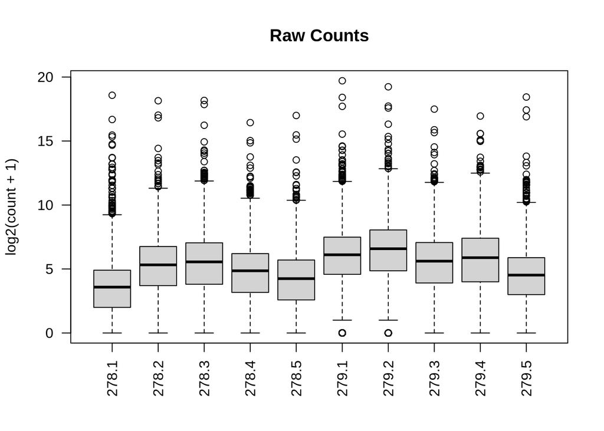

```r
boxplot(log2(df_stm + 1),
        main = "Raw Counts",
        ylab = "log2(count + 1)",
        las = 2)
```

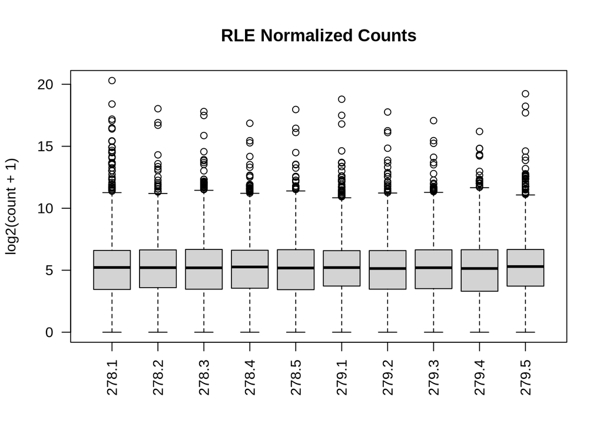

```r
boxplot(log2(normalized_counts + 1),
        main = "RLE Normalized Counts",
        ylab = "log2(count + 1)",
        las = 2)
```

## Mean of the Normalized Count for 278.1 - 278.5 and 279.1 - 279.5

```r
mixed_stm_samples = grep("278", colnames(normalized_counts), value = TRUE)
stm_samples = grep("279", colnames(normalized_counts), value = TRUE)

mean_mixed_stm_samples = rowMeans(normalized_counts[, mixed_stm_samples])
mean_stm_samples = rowMeans(normalized_counts[, stm_samples])

head(mean_mixed_stm_samples)
```

```
##   STM0001   STM0002   STM0003   STM0004   STM0005   STM0006
##  44.24939 119.40562  60.74858 128.54819  64.01150  49.02044
```

```r
head(mean_stm_samples)
```

```
##   STM0001   STM0002   STM0003   STM0004   STM0005   STM0006
##  49.29464 126.93926  70.85171 133.97034  60.99403  56.59343
```

## Compare the Average Samples 278 and 279

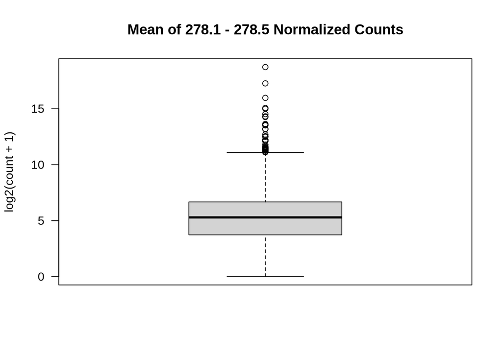

```r
boxplot(log2(mean_mixed_stm_samples + 1),
        main = "Mean of 278.1 - 278.5 Normalized Counts",
        ylab = "log2(count + 1)",
        las = 2)
```

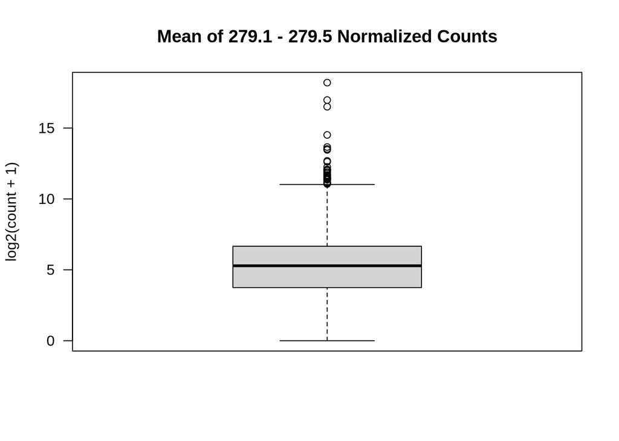

```r
boxplot(log2(mean_stm_samples + 1),
        main = "Mean of 279.1 - 279.5 Normalized Counts",
        ylab = "log2(count + 1)",
        las = 2)
```

## Checks to ensure the gene name lengths are the same across all tables

```r
# check that the count of gene_ids is the same in the mean of the 278 and 278 samples.
length(mean_mixed_stm_samples)
```

```
## [1] 4671
```

```r
length(mean_stm_samples)
```

```
## [1] 4671
```

```r
# check that the count of gene_ids in the normalized counts table is the same.
nrow(normalized_counts)
```

```
## [1] 4671
```

```r
# check that the names of the gene_ids are the same in the the normalized counts table, the mean of 278 table, and the mean of 279 table
head(names(mean_mixed_stm_samples))
```

```
## [1] "STM0001" "STM0002" "STM0003" "STM0004" "STM0005" "STM0006"
```

```r
head(names(mean_stm_samples))
```

```
## [1] "STM0001" "STM0002" "STM0003" "STM0004" "STM0005" "STM0006"
```

```r
head(rownames(normalized_counts))
```

```
## [1] "STM0001" "STM0002" "STM0003" "STM0004" "STM0005" "STM0006"
```

## Create a thresholding Function

Create a function that takes a numeric vector of mean normalized counts and a low and a high quantile cut off. If the normalized gene count is higher than the high quantile, it is assigned a 1. If the If the normalized gene count is lower than the low quantile, it is assigned a -1. All remaining gene counts are assigned a 0.

```r
thresholding_function = function(expr_vector, low_q, high_q) {

  low  = quantile(expr_vector, low_q)
  high = quantile(expr_vector, high_q)

  ifelse(expr_vector > high, 1,
         ifelse(expr_vector < low, -1, 0))
}
```

## Apply the thresholds to both sample types

Apply the thresholding function to the mean counts for each condition and apply three threshold stringencies: 25/75, 15/85, and 10/90.

```r
# threshold the mean of samples 278.1-278.5 ---- mean_mixed_stm_samples (cs/bth/stm)
mixed_stm_threshold_25_75 = thresholding_function(mean_mixed_stm_samples, 0.25, 0.75)
mixed_stm_threshold_10_90 = thresholding_function(mean_mixed_stm_samples, 0.10, 0.90)
mixed_stm_threshold_15_85 = thresholding_function(mean_mixed_stm_samples, 0.15, 0.85)

# count how many there are in each bin
table(mixed_stm_threshold_25_75)
```

```
## mixed_stm_threshold_25_75
##   -1    0    1
## 1168 2335 1168
```

```r
table(mixed_stm_threshold_10_90)
```

```
## mixed_stm_threshold_10_90
##   -1    0    1
##  467 3737  467
```

```r
table(mixed_stm_threshold_15_85)
```

```
## mixed_stm_threshold_15_85
##   -1    0    1
##  701 3269  701
```

```r
# threshold the mean of samples 279.1-279.5 ---- mean_stm_samples (stm only)
stm_threshold_25_75 = thresholding_function(mean_stm_samples, 0.25, 0.75)
stm_threshold_10_90 = thresholding_function(mean_stm_samples, 0.10, 0.90)
stm_threshold_15_85 = thresholding_function(mean_stm_samples, 0.15, 0.85)

# count how many there are in each bin
table(stm_threshold_25_75)
```

```
## stm_threshold_25_75
##   -1    0    1
## 1168 2335 1168
```

```r
table(stm_threshold_10_90)
```

```
## stm_threshold_10_90
##   -1    0    1
##  467 3737  467
```

```r
table(stm_threshold_15_85)
```

```
## stm_threshold_15_85
##   -1    0    1
##  701 3269  701
```

## Make dataframes of the threshold values

```r
# make named vectors into a dataframe

df_stm_threshold_10_90 = data.frame("genes" = names(stm_threshold_10_90),
                                    "threshold_category" = stm_threshold_10_90)
df_stm_threshold_25_75 = data.frame("genes" = names(stm_threshold_25_75),
                                    "threshold_category" = stm_threshold_25_75)
df_stm_threshold_15_85 = data.frame("genes" = names(stm_threshold_15_85),
                                    "threshold_category" = stm_threshold_15_85)

df_mixed_stm_threshold_10_90 = data.frame("genes" = names(mixed_stm_threshold_10_90),
                                    "threshold_category" = mixed_stm_threshold_10_90)
df_mixed_stm_threshold_25_75 = data.frame("genes" = names(mixed_stm_threshold_25_75),
                                    "threshold_category" = mixed_stm_threshold_25_75)
df_mixed_stm_threshold_15_85 = data.frame("genes" = names(mixed_stm_threshold_15_85),
                                    "threshold_category" = mixed_stm_threshold_15_85)
print(df_stm_threshold_10_90)
```

[output not shown]

[output cut: 4617 more lines]

[output not shown]

## Save threshold values as CSV

```r
write_csv(df_stm_threshold_10_90, file = "/home/gmvaz/2026_GEMs/imat_prep_test/stm_threshold_10_90.csv")
write_csv(df_stm_threshold_25_75, file = "/home/gmvaz/2026_GEMs/imat_prep_test/stm_threshold_25_75.csv")
write_csv(df_stm_threshold_15_85, file = "/home/gmvaz/2026_GEMs/imat_prep_test/stm_threshold_15_85.csv")

write_csv(df_mixed_stm_threshold_10_90, file = "/home/gmvaz/2026_GEMs/imat_prep_test/mixed_stm_threshold_10_90.csv")
write_csv(df_mixed_stm_threshold_25_75, file = "/home/gmvaz/2026_GEMs/imat_prep_test/mixed_stm_threshold_25_75.csv")
write_csv(df_mixed_stm_threshold_15_85, file = "/home/gmvaz/2026_GEMs/imat_prep_test/mixed_stm_threshold_15_85.csv")
```

## Create a Comparison Function

Create a function to compare how many genes are high and low in each condition.

```r
compare_thresholds = function(mixed_vec, stm_vec) {
  # extract the names of the high genes in the mixed_stm list
  # extract the names of the low genes in the mixed_stm list
  mixed_high = names(mixed_vec)[mixed_vec == 1]
  mixed_low  = names(mixed_vec)[mixed_vec == -1]

  # extract the names of the high genes in the stm list
  # extract the names of the low genes in the stm list
  stm_high = names(stm_vec)[stm_vec == 1]
  stm_low = names(stm_vec)[stm_vec == -1]

  # For high genes:
  # which genes are high in both sets
  # which genes are high only in the mixed set
  # which genes are high only in the stm set
  list(
    high = list(
      overlap = intersect(mixed_high, stm_high),
      mixed_only = setdiff(mixed_high, stm_high),
      stm_only = setdiff(stm_high, mixed_high)
    ),
      # For low genes:
  # which genes are low in both sets
  # which genes are low only in the mixed set
  # which genes are low only in the stm set
    low = list(
      overlap = intersect(mixed_low, stm_low),
      mixed_only = setdiff(mixed_low, stm_low),
      stm_only = setdiff(stm_low, mixed_low)
    )
  )
}
```

## Apply the Comparison Function with all three thresholds

```r
## make visual gene lists
# use the compare_thresholds function with all three thresholds
comparison_25_75 = compare_thresholds(mixed_stm_threshold_25_75,
                                        stm_threshold_25_75)

comparison_10_90 = compare_thresholds(mixed_stm_threshold_10_90,
                                        stm_threshold_10_90)

comparison_15_85 = compare_thresholds(mixed_stm_threshold_15_85,
                                        stm_threshold_15_85)
```

## Create reports that compare genes as high or low and either: overlap between both groups or are present in only one group

```r
report_25_75 = data.frame(
  high_overlap      = length(comparison_25_75$high$overlap),
  high_mixed_only   = length(comparison_25_75$high$mixed_only),
  high_stm_only     = length(comparison_25_75$high$stm_only),
  low_overlap       = length(comparison_25_75$low$overlap),
  low_mixed_only    = length(comparison_25_75$low$mixed_only),
  low_stm_only      = length(comparison_25_75$low$stm_only)
)

report_15_85 = data.frame(
  high_overlap      = length(comparison_15_85$high$overlap),
  high_mixed_only   = length(comparison_15_85$high$mixed_only),
  high_stm_only     = length(comparison_15_85$high$stm_only),
  low_overlap       = length(comparison_15_85$low$overlap),
  low_mixed_only    = length(comparison_15_85$low$mixed_only),
  low_stm_only      = length(comparison_15_85$low$stm_only)
)

  report_10_90 = data.frame(
  high_overlap      = length(comparison_10_90$high$overlap),
  high_mixed_only   = length(comparison_10_90$high$mixed_only),
  high_stm_only     = length(comparison_10_90$high$stm_only),
  low_overlap       = length(comparison_10_90$low$overlap),
  low_mixed_only    = length(comparison_10_90$low$mixed_only),
  low_stm_only      = length(comparison_10_90$low$stm_only)
)

report_25_75
```

```
##   high_overlap high_mixed_only high_stm_only low_overlap low_mixed_only
## 1         1067             101           101        1089             79
##   low_stm_only
## 1           79
```

```r
report_15_85
```

```
##   high_overlap high_mixed_only high_stm_only low_overlap low_mixed_only
## 1          631              70            70         636             65
##   low_stm_only
## 1           65
```

```r
report_10_90
```

```
##   high_overlap high_mixed_only high_stm_only low_overlap low_mixed_only
## 1          418              49            49         412             55
##   low_stm_only
## 1           55
```

## The total amount of genes classified as high in one condition and not the other (and same for low)

```r
report_25_75$high_differ = report_25_75$high_mixed_only + report_25_75$high_stm_only
report_25_75$low_differ  = report_25_75$low_mixed_only  + report_25_75$low_stm_only

report_15_85$high_differ = report_15_85$high_mixed_only + report_15_85$high_stm_only
report_15_85$low_differ  = report_15_85$low_mixed_only  + report_15_85$low_stm_only

report_10_90$high_differ = report_10_90$high_mixed_only + report_10_90$high_stm_only
report_10_90$low_differ  = report_10_90$low_mixed_only  + report_10_90$low_stm_only

report_25_75
```

```
##   high_overlap high_mixed_only high_stm_only low_overlap low_mixed_only
## 1         1067             101           101        1089             79
##   low_stm_only high_differ low_differ
## 1           79         202        158
```

```r
report_15_85
```

```
##   high_overlap high_mixed_only high_stm_only low_overlap low_mixed_only
## 1          631              70            70         636             65
##   low_stm_only high_differ low_differ
## 1           65         140        130
```

```r
report_10_90
```

```
##   high_overlap high_mixed_only high_stm_only low_overlap low_mixed_only
## 1          418              49            49         412             55
##   low_stm_only high_differ low_differ
## 1           55          98        110
```